# Test a Perceptual Phenomenon

### Analyzing the Stroop Effect

Perform the analysis in the space below. Remember to follow [the instructions](https://docs.google.com/document/d/1-OkpZLjG_kX9J6LIQ5IltsqMzVWjh36QpnP2RYpVdPU/pub?embedded=True) and review the [project rubric](https://review.udacity.com/#!/rubrics/71/view) before submitting. Once you've completed the analysis and write-up, download this file as a PDF or HTML file, upload that PDF/HTML into the workspace here (click on the orange Jupyter icon in the upper left then Upload), then use the Submit Project button at the bottom of this page. This will create a zip file containing both this .ipynb doc and the PDF/HTML doc that will be submitted for your project.

(1) What is the independent variable? What is the dependent variable?

**Independent variable:** the congruency condition including congruent words condition and incongruent words condition.

**Dependent variable:** the response time for each participant to name the ink color.

(2) What is an appropriate set of hypotheses for this task? Specify your null and alternative hypotheses, and clearly define any notation used. Justify your choices.

**Null hypothesis ($H_0$):** $ \mu_i = \mu_c $ (Population mean of Incongurent = Population mean of Congurent)

**Alternative hypothesis ($H_1$):** $ \mu_i$ ≠ $\mu_c $ (Population mean of Incongurent ≠ Population mean of Congurent)

**Proposed test:** Two-tailed t-test because it compares the mean of two paired groups to see if there are statistically significant differences between these two means.

(3) Report some descriptive statistics regarding this dataset. Include at least one measure of central tendency and at least one measure of variability. The name of the data file is 'stroopdata.csv'.

```python
# Perform the analysis here

#Imports
import pandas as pd

#Read data
data = pd.read_csv("stroopdata.csv")
data.head()
```

|  | Congruent | Incongruent |
| --- | --- | --- |
| 0 | 12.079 | 19.278 |
| 1 | 16.791 | 18.741 |
| 2 | 9.564 | 21.214 |
| 3 | 8.630 | 15.687 |
| 4 | 14.669 | 22.803 |

```python
#Mean
congurent_mean = data['Congruent'].mean()
incongurent_mean = data['Incongruent'].mean()
[congurent_mean, incongurent_mean]
```

```
[14.051124999999999, 22.015916666666666]
```

```python
#Standard deviation
congurent_std = data['Congruent'].std()
incongurent_std = data['Incongruent'].std()
[congurent_std, incongurent_std]
```

```
[3.5593579576451955, 4.7970571224691376]
```

```python
#Equivalent statistics function to confirm calculated values
data.describe()
```

|  | Congruent | Incongruent |
| --- | --- | --- |
| count | 24.000000 | 24.000000 |
| mean | 14.051125 | 22.015917 |
| std | 3.559358 | 4.797057 |
| min | 8.630000 | 15.687000 |
| 25% | 11.895250 | 18.716750 |
| 50% | 14.356500 | 21.017500 |
| 75% | 16.200750 | 24.051500 |
| max | 22.328000 | 35.255000 |

### Congurent

**Sample Size:** 24

**Mean:** 14.05

**Median:** 14.356

**Standard Deviation:** 3.559

**Q1:** 11.895

**Q3:** 16.2

**Interquartile range:** 4.305

### Incongurent

**Sample Size:** 24

**Mean:** 22.016

**Median:** 21.017

**Standard Deviation:** 4.797

**Q1:** 18.716

**Q3:** 24.051

**Interquartile range:** 5.335

(4) Provide one or two visualizations that show the distribution of the sample data. Write one or two sentences noting what you observe about the plot or plots.

```python
# Build the visualizations here

#Imports
import seaborn as sns
import matplotlib.pyplot as plt

#Box plot showing congurent/incongurent data distribution
sns.boxplot(data=data[['Congruent', 'Incongruent']], orient="v",width=0.4, palette="colorblind");
plt.ylabel("Time");
```

[output not shown]

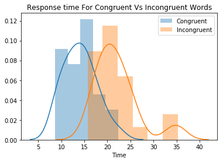

```python
#Draw the distributions of each dataset
sns.distplot(data['Congruent'],label = "Congruent")
sns.distplot(data['Incongruent'],label = "Incongruent")
plt.xlabel("Time");
plt.title("Response time For Congruent Vs Incongruent Words");
plt.legend();
```

- Both Congurent and Incongurent data follows a normal distribution (If we exclude the outliers of the Incongurent data)

(5) Now, perform the statistical test and report your results. What is your confidence level or Type I error associated with your test? What is your conclusion regarding the hypotheses you set up? Did the results match up with your expectations? **Hint:** Think about what is being measured on each individual, and what statistic best captures how an individual reacts in each environment.

Assume confidence Interval: 95%

Sample size (n) = 24

Degree of freedom (df) = n-1 = 23

```python
# Perform the statistical test here

#Imports
from scipy.stats import t as pt
import math

#Calculate t-critical (t*)
t_critical = pt.ppf(0.975,23)
t_critical
```

```
2.0686576104190406
```

```python
#Calculate the difference in data
data['Difference'] = data['Congruent'] - data['Incongruent']
data.head()
```

|  | Congruent | Incongruent | Difference |
| --- | --- | --- | --- |
| 0 | 12.079 | 19.278 | -7.199 |
| 1 | 16.791 | 18.741 | -1.950 |
| 2 | 9.564 | 21.214 | -11.650 |
| 3 | 8.630 | 15.687 | -7.057 |
| 4 | 14.669 | 22.803 | -8.134 |

```python
#Mean and standard deviation of Difference
difference_mean = congurent_mean - incongurent_mean
difference_std = data['Difference'].std()
difference_std
```

```
4.8648269103590556
```

```python
# Calculate the t-value
t_value = difference_mean/(difference_std/math.sqrt(24))
t_value
```

```
-8.020706944109957
```

t_value is much less than t_critical, therefore we have to **reject** the Null hypothesis in favor of the Alternative hypothesis at α = 0.05. Therefore, people name words that have meaning matching its color faster than when they don't match, which confirms my expectation that it's tricky when they don't match, so it needs more time.

(6) Optional: What do you think is responsible for the effects observed? Can you think of an alternative or similar task that would result in a similar effect? Some research about the problem will be helpful for thinking about these two questions!

In my opinion, brain faces a confusion when both the word and its color don't match, it attempts to read the word first, but then finds out its color is different from the read word, so it takes some more time to reject the read word and move forward with the color itself.

A similar problem is the reverse stroop effect, we say out the word instead of the color of the word.